# Reproducible online supplementary material

Rachel Heyard et al. (2021)

This online supplement reproduces all the Figures and Tables presented in the publication “Rethinking the Funding Line at the Swiss National Science Foundation: Bayesian Ranking and Lottery”. The methodology of the expected rank (ER) for grant peer review is fully implemented in the `R` package `{ERforResearch}` downloadable from [github](https://github.com/snsf-data/ERforResearch) with [documentation](https://snsf-data.github.io/ERforResearch/). To install the package, the following code can be used:

```r
# Install ERforResearch from github:
# devtools::install_github("snsf-data/ERforResearch")
library(ERforResearch)
```

```r
## Some helper functions for later:
# Function to extract the Intraclass correlation coefficient (ICC) from the
# matrix of individual votes:
get_icc_from_matrix <- function(individual_votes) {
  (individual_votes %>%
     select(-proposal) %>%
     mutate_all(function(x) ERforResearch:::get_num_grade_snsf(x)) %>%
     as.data.frame() %>%
     psych::ICC(x = ., missing = FALSE))$results %>%
    filter(type == "ICC3") %>% # A fixed set of k judges rates each target
    mutate(icc = paste0(round(ICC, 2), " (",
                        round(`lower bound`, 2), "; ",
                        round(`upper bound`, 2), ")")) %>%
    pull(icc) %>%
    return()
}

# Function to graphically represent all the votes, and the ICC from the
# matrix of individual votes:
get_grades_plot <- function(long_individual_votes, individual_votes_mat = NULL,
                            x_min = NULL, x_max = NULL, title = "",
                            jitter_h = .02, jitter_w = .025,
                            jitter_alpha = .5){
  if (is.null(x_min)){
    x_min <- long_individual_votes %>% pull(num_grade) %>% min
    x_min <- ifelse(x_min > 1, x_min - 1.2, x_min -.2)
  }
  if (is.null(x_max)){
    x_max <- long_individual_votes %>% pull(num_grade) %>% max
    x_max <- ifelse(x_max < 6, x_max + 1.2, x_max +.2)
  }
  if (!is.null(individual_votes_mat)){
    icc <- get_icc_from_matrix(individual_votes_mat)
    title <- paste0(ifelse(title == "", "ICC = ",
                           paste0(title, ": ICC = ")), icc)
  }
  plot_data <- long_individual_votes %>%
    group_by(proposal) %>%
    mutate(avg = mean(num_grade, na.rm = TRUE)) %>%
    ungroup()
  plot_data <- plot_data %>%
    select(proposal, avg) %>%
    distinct() %>%
    arrange(avg) %>%
    mutate(order = 1:n()) %>%
    select(-avg) %>%
    left_join(plot_data, by = "proposal")
  plot_data %>%
    ggplot(aes(x = num_grade, y = order)) +
    geom_jitter(aes(color = "Individual Votes"), height = jitter_h,
                width = jitter_w, alpha = jitter_alpha, size = 1) +
    geom_point(aes(x = avg, color = "Average"), size = 1.5) +
    theme_minimal() +
    scale_y_continuous(breaks = unique(plot_data$order),
                       labels =
                         as.numeric(str_extract_all(unique(plot_data$proposal),
                                                    "[0-9]+"))) +
    labs(x = "Assessor Vote", y = "Ordered proposal", title = title) +
    lims(x = c(x_min, x_max)) +
    scale_color_manual(name = " ",
                       values = c("Average"="#FF6F6F",
                                  "Individual Votes" = "#848383")) +
    theme(axis.text.y = element_blank(),
          legend.position = c(0.5, .5),
          axis.title.y = element_blank(),
          panel.grid.major.y = element_line(size = .1))
}


# Bland-Altman Plot for Agreement:
get_agreement_plot <- function(rankings, rankings_ordinal, title, ymin = -.5,
                               ymax = .5, pt_alpha = .8, pt_size = 1){
  difference <- rankings %>%
    select(id_application, er) %>%
    rename(er1 = er) %>%
    left_join(rankings_ordinal %>%
                select(id_application, er) %>%
                rename(er2 = er),
              by = "id_application") %>%
    mutate(difference = er1 - er2,
           avg = (er1 + er2)/2) %>%
    select(id_application, difference, avg)

  d <- difference %>%
    summarise(mean(difference)) %>% pull
  sd <- difference %>%
    summarise(sd(difference)) %>% pull
  difference %>%
    ggplot(aes(x = avg, y = difference)) +
    geom_point(alpha = pt_alpha, size = pt_size) +
    geom_hline(yintercept = d, color = "gray") +
    geom_hline(yintercept = d - 1.96 * sd, color = "darkred", lty = "dotted") +
    geom_hline(yintercept = d + 1.96 * sd, color = "darkred", lty = "dotted") +
    ylim(ymin, ymax) +
    labs(y = "Difference in ER", x = "Average ER of both approaches",
         title = title) +
    snf.plot::snsf_theme
}
# Percentile Loss Function
percentile_loss <- function(true_rank, estimated_rank, perc = .3, p = 2,
                            q = 2, c = 1){
  I <- length(true_rank)
  true_percentile <- true_rank / (I + 1)
  estimated_percentile <- estimated_rank / (I + 1)
  AB <- (true_percentile > perc) & (estimated_percentile < perc)
  BA <- (true_percentile < perc) & (estimated_percentile > perc)

  loss <- (sum(abs(perc - estimated_percentile)^p * AB +
                 c * abs(estimated_percentile - perc)^q * BA)) / I
  return(loss)
}
```

The main paper presents two major case studies. The methodology of the Bayesian Ranking (BR) is applied to give funding recommendations for two funding instruments at the Swiss National Science Foundation(SNSF): the *Postdoc.Mobility* fellowship for early career researchers and the SNSF *Project Funding* scheme. The data for both case studies is available on [Zenodo](https://zenodo.org/record/4531160#.YCQFZehKh3g) and can accessed directly through `R` using the following code chunk:

```r
# Load the data from Zenodo:
path_to_xlsx <- "https://zenodo.org/record/4531160/files/individual_votes.xlsx"

hss_s_mat <- openxlsx::read.xlsx(xlsxFile = path_to_xlsx, sheet = "pm_hsss")
hss_s <- hss_s_mat %>%
  get_right_data_format(prefix_voter = "voter")

hss_h_mat <- openxlsx::read.xlsx(xlsxFile = path_to_xlsx, sheet = "pm_hssh")
hss_h <- hss_h_mat %>%
  get_right_data_format(prefix_voter = "voter")

ls_b_mat <- openxlsx::read.xlsx(xlsxFile = path_to_xlsx, sheet = "pm_lsb")
ls_b <- ls_b_mat %>%
  get_right_data_format(prefix_voter = "voter")

ls_m_mat <- openxlsx::read.xlsx(xlsxFile = path_to_xlsx, sheet = "pm_lsm")
ls_m <- ls_m_mat %>%
  get_right_data_format(prefix_voter = "voter")

stem_mat <- openxlsx::read.xlsx(xlsxFile = path_to_xlsx, sheet = "pm_stem")
stem <- stem_mat %>%
  get_right_data_format(prefix_voter = "voter")

mint_section1_mat <-
  openxlsx::read.xlsx(xlsxFile = path_to_xlsx, sheet = "mint_section1")
mint_section1 <- mint_section1_mat %>%
  get_right_data_format(prefix_voter = "voter") %>%
  mutate(section = "one")

mint_section2_mat <-
  openxlsx::read.xlsx(xlsxFile = path_to_xlsx, sheet = "mint_section2")
mint_section2 <- mint_section2_mat %>%
  get_right_data_format(prefix_voter = "voter") %>%
  mutate(section = "two")

mint_section3_mat <-
  openxlsx::read.xlsx(xlsxFile = path_to_xlsx, sheet = "mint_section3")
mint_section3 <- mint_section3_mat %>%
  get_right_data_format(prefix_voter = "voter") %>%
  mutate(section = "three")

mint_section4_mat <-
  openxlsx::read.xlsx(xlsxFile = path_to_xlsx, sheet = "mint_section4")
mint_section4 <- mint_section4_mat %>%
  get_right_data_format(prefix_voter = "voter") %>%
  mutate(section = "four")

# Note that we want to be able to differentiate the proposals in the different
# mint sections
mint_sections <- mint_section1 %>%
  mutate(proposal = paste0(proposal, "_1")) %>%
  bind_rows(mint_section2%>%
              mutate(proposal = paste0(proposal, "_2"))) %>%
  bind_rows(mint_section3%>%
              mutate(proposal = paste0(proposal, "_3"))) %>%
  bind_rows(mint_section4%>%
              mutate(proposal = paste0(proposal, "_4")))

##### How many projects can still be funded? ####
how_many_fundable <- c(7, 4, 7, 8, 6)
names(how_many_fundable) <- c("hss_s", "hss_h", "ls_m", "ls_b", "stem")
```

# 1 Postdoc.Mobility funding scheme

The fist case study focuses on the evaluation of the [Postdoc.Mobility (PM)](http://www.snf.ch/en/funding/careers/postdoc-mobility/Pages/default.aspx) Call of February 1st 2020. Junior researchers who have recently defended their PhD and wish to pursue an academic career can apply for a PM fellowship, which will allow them to work in a research group abroad for two years. The researchers submit their research proposal to the SNSF, which is then evaluated by two referees who score the proposal on a six-point scale (1 being poor quality and 6 being outstanding quality). Each proposal is evaluated by one of the following panels: Humanities; Social Sciences; Science, Technology, Engineering and Mathematics (STEM); Medicine; and Biology. As described in the main paper, the dataset on the PM panels contains the evaluation of the assessors on the proposals which were triaged into the ‘panel discussion’ group (*e*.*g*. not directly accepted, nor rejected). Each panel has their own available funding, so that five different funding lines are drawn. The proposals are discussed in the respective panel, where each member votes on a score for each of the proposals, unless they have a conflict of interest or another reason to be absent during the voting. Table 1.1 summarizes the number of proposals in the different ‘panel discussion’ groups together with the number of proposals that can still be funded and the size of the panel.

Table 1.1: Characteristics of panels and submissions for the February 2020 call for junior fellowships at the Swiss National Science Foundation.

|  | N. of panel members | Total N. of submissions | N. of proposals discussed | N. of fundable proposals |
| --- | --- | --- | --- | --- |
| Humanities | 14 | 23 | 11 | 4 |
| Social Sciences | 14 | 38 | 18 | 7 |
| Biology | 26 | 35 | 18 | 8 |
| Medicine | 17 | 35 | 14 | 7 |
| STEM | 29 | 50 | 18 | 6 |

For each of the five panels, Figure 1.1 presents the votes of the panel members to each of the proposals discussed. The proposals are represented on the y-axis, and ordered depending on the average of the individual votes they got (red dots). We see a large variability in the votes. Note that we only consider the middle block of proposals that were neither truly exceptional nor of very low quality and that the variability of the votes per proposals tends to be larger in the middle block than for proposals a with very low/high average score. Some of the members of the STEM panel still assessed a few proposals with a 2, which is the second lowest grade; not surprisingly the STEM panel has the lowest intraclass correlation (ICC), representing the assessor reliability. In all 5 panels, the assessor reliability can be classified as either poor or fair.

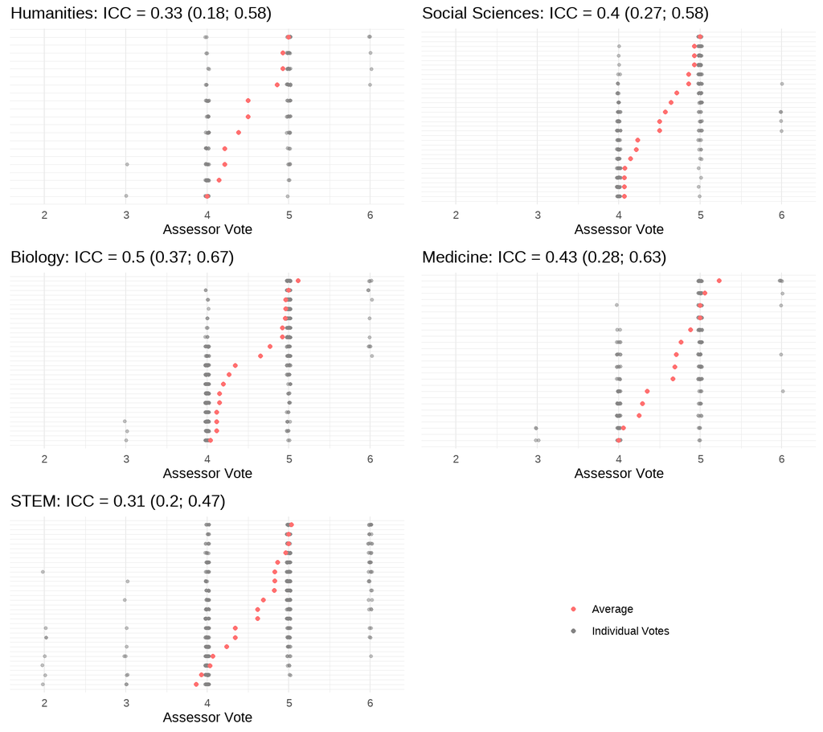

Figure 1.1: The individual votes given to all proposals by all panel members. The red dots represent the averages of those individual votes for each proposal. The intra-class correlation coefficients together with their 95% confidence intervals of the different panels can be found in the titles of the subfigures. In all panels, the assessor reliability can be classified as poor to fair.

```r
leg <- cowplot::get_legend(get_grades_plot(hss_h))
gridExtra::grid.arrange(get_grades_plot(hss_h, hss_h_mat, x_min = 1.8,
                                        title = "Humanities") +
                          theme(legend.position = "none"),
                        get_grades_plot(hss_s, hss_s_mat, x_min = 1.8,
                                        title = "Social Sciences") +
                          theme(legend.position = "none"),
                        get_grades_plot(ls_b, ls_b_mat, x_min = 1.8,
                                        title = "Biology")+
                          theme(legend.position = "none"),
                        get_grades_plot(ls_m, ls_m_mat, x_min = 1.8,
                                        title = "Medicine")+
                          theme(legend.position = "none"),
                        get_grades_plot(stem, stem_mat, x_min = 1.8,
                                        title = "STEM")+
                          theme(legend.position = "none"),
                        leg)
```

Then, the Bayesian hierarchical models will be fitted for each of the five panels individually and the expected ranks will be retrieved using the MCMC samples from the latter models. Note that the number of iterations, burnin and adaptation (`n.iter`, `n.burnin` and `n.adapt`) are set high enough to ensure convergence of all the MCMC chains. Lower number of iterations etc, will make the code run faster.

```r
##### The model for JAGS ####
# we will use the default

##### Get the ER results: ####
# To make the code run faster, make sure to decrease those numbers
n.iter <- 50 * 10^{3}
n.burnin <- 10 * 10^{3}
n.adapt <- 10 * 10^{3}
max.iter <- 50 * 10^{3}
n.chains <- 4
seed <- 1991
# as we checked the number of iterations etc needed for convergence before,
# the argument max_iter set to the same as n.iter ensures that the algorithm is
# not rerun until convergence, but only once.
mcmc_hss_s_object <-
  get_mcmc_samples(data = hss_s,
                   id_application = "proposal",
                   id_voter = "voter",
                   grade_variable = "num_grade",
                   n_chains = n.chains, n_iter = n.iter,
                   n_burnin = n.burnin, n_adapt = n.adapt,
                   max_iter =  max.iter,
                   variables_to_sample = "specified",
                   rhat_threshold = 1.1,
                   names_variables_to_sample =
                     c("application_intercept", "tau_application",
                       "nu", "tau_voter", "rank_theta", "sigma"),
                   inits_type = "random",
                   seed = seed, quiet = TRUE, dont_bind = TRUE)
mcmc_hss_s <- mcmc(do.call(rbind, mcmc_hss_s_object))

mcmc_hss_h_object <-
  get_mcmc_samples(data = hss_h,
                   id_application = "proposal",
                   id_voter = "voter",
                   grade_variable = "num_grade",
                   n_chains = n.chains, n_iter = n.iter,
                   n_burnin = n.burnin, n_adapt = n.adapt,
                   max_iter =  max.iter,
                   variables_to_sample = "specified",
                   rhat_threshold = 1.1,
                   names_variables_to_sample =
                     c("application_intercept", "tau_application",
                       "nu", "tau_voter", "rank_theta", "sigma"),
                   inits_type = "random",
                   seed = seed, quiet = TRUE, dont_bind = TRUE)
mcmc_hss_h <- mcmc(do.call(rbind, mcmc_hss_h_object))

mcmc_ls_b_object <-
  get_mcmc_samples(data = ls_b,
                   id_application = "proposal",
                   id_voter = "voter",
                   grade_variable = "num_grade",
                   n_chains = n.chains, n_iter = n.iter,
                   n_burnin = n.burnin, n_adapt = n.adapt,
                   max_iter =  max.iter,
                   variables_to_sample = "specified",
                   rhat_threshold = 1.1,
                   names_variables_to_sample =
                     c("application_intercept", "tau_application",
                       "nu", "tau_voter", "rank_theta", "sigma"),
                   inits_type = "random",
                   seed = seed, quiet = TRUE, dont_bind = TRUE)
mcmc_ls_b <- mcmc(do.call(rbind, mcmc_ls_b_object))

mcmc_ls_m_object <-
  get_mcmc_samples(data = ls_m,
                   id_application = "proposal",
                   id_voter = "voter",
                   grade_variable = "num_grade",
                   n_chains = n.chains, n_iter = n.iter,
                   n_burnin = n.burnin, n_adapt = n.adapt,
                   max_iter =  max.iter,
                   variables_to_sample = "specified",
                   rhat_threshold = 1.1,
                   names_variables_to_sample =
                     c("application_intercept", "tau_application",
                       "nu", "tau_voter", "rank_theta", "sigma"),
                   inits_type = "random",
                   seed = seed, quiet = TRUE, dont_bind = TRUE)
mcmc_ls_m <- mcmc(do.call(rbind, mcmc_ls_m_object))

mcmc_stem_object <-
  get_mcmc_samples(data = stem,
                   id_application = "proposal",
                   id_voter = "voter",
                   grade_variable = "num_grade",
                   n_chains = n.chains, n_iter = n.iter,
                   n_burnin = n.burnin, n_adapt = n.adapt,
                   max_iter =  max.iter,
                   variables_to_sample = "specified",
                   rhat_threshold = 1.1,
                   names_variables_to_sample =
                     c("application_intercept", "tau_application",
                       "nu", "tau_voter", "rank_theta", "sigma"),
                   inits_type = "random",
                   seed = seed, quiet = TRUE, dont_bind = TRUE)

mcmc_stem <- mcmc(do.call(rbind, mcmc_stem_object))


# Computation of the ER and PCER:
ranks_hss_s <- get_er_from_jags(data = hss_s,
                                id_application = "proposal",
                                id_voter = "voter",
                                grade_variable = "num_grade",
                                mcmc_samples = mcmc_hss_s_object)

ranks_hss_h <- get_er_from_jags(data = hss_h,
                                id_application = "proposal",
                                id_voter = "voter",
                                grade_variable = "num_grade",
                                mcmc_samples = mcmc_hss_h_object)

ranks_ls_b <- get_er_from_jags(data = ls_b,
                               id_application = "proposal",
                               id_voter = "voter",
                               grade_variable = "num_grade",
                               mcmc_samples = mcmc_ls_b_object)

ranks_ls_m <- get_er_from_jags(data = ls_m,
                               id_application = "proposal",
                               id_voter = "voter",
                               grade_variable = "num_grade",
                               mcmc_samples = mcmc_ls_m_object)

ranks_stem <- get_er_from_jags(data = stem,
                               id_application = "proposal",
                               id_voter = "voter",
                               grade_variable = "num_grade",
                               mcmc_samples = mcmc_stem_object)
```

Figure 1.2 presents the different stages of ranking of the proposals for all panels. The first column of points in the figure represents ranking based on the simple averages (Fixed). Then the proposals are ranked based on the posterior means of *θ*<sub>*i*</sub> (Posterior Mean) and finally, the last column of points the expected rank. A naive funding line as represented by the color code in the figure is defined by simply funding the *x* best ranked proposals, where *x* can be retrieved from Table 1.1.

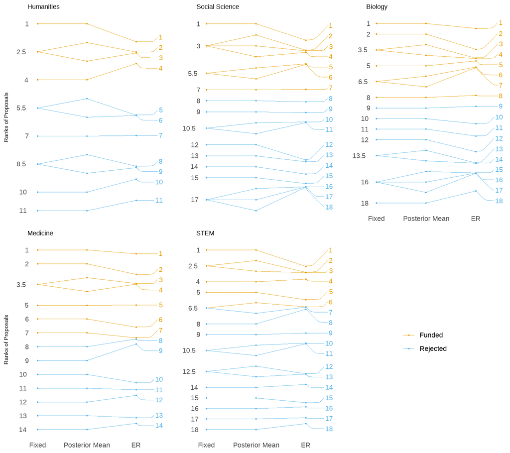

Figure 1.2: PM fellowship proposals discussed in the different panels ranked using the average overall score (Fixed), the posterior means of the parameter *θ*<sub>*i*</sub> and the ER. The color code shows which proposals would be funded, if the SNSF simply funds the *x* best proposals based on the ER, where *x* is panel-specific and shown in Table 1.1. Points representing tied proposals are on top of each other, but noticable as such because of the numbers.

```r
##### Plot the results ####
plot_hss_s <-
  plotting_er_results(ranks_hss_s, result_show = TRUE, title = "Social Science",
                      id_application = "id_application",
                      pt_size = .5, line_size = .2, draw_funding_line = FALSE,
                      line_type_fl = "longdash", color_fl = "darkgray", grep_size = 3,
                      how_many_fundable = how_many_fundable["hss_s"])

plot_hss_h <-
  plotting_er_results(ranks_hss_h, result_show = TRUE, title = "Humanities",
                      id_application = "id_application",
                      pt_size = .5, line_size = .2, draw_funding_line = FALSE,
                      line_type_fl = "longdash", color_fl = "darkgray", grep_size = 3,
                      how_many_fundable = how_many_fundable["hss_h"])

plot_ls_b <-
  plotting_er_results(ranks_ls_b, result_show = TRUE, title = "Biology",
                      id_application = "id_application",
                      pt_size = .5, line_size = .2, draw_funding_line = FALSE,
                      line_type_fl = "longdash", color_fl = "darkgray", grep_size = 3,
                      how_many_fundable = how_many_fundable["ls_b"])

plot_ls_m <-
   plotting_er_results(ranks_ls_m, result_show = TRUE, title = "Medicine",
                      id_application = "id_application",
                      pt_size = .5, line_size = .2, draw_funding_line = FALSE,
                      line_type_fl = "longdash", color_fl = "darkgray", grep_size = 3,
                      how_many_fundable = how_many_fundable["ls_m"])

plot_stem <-
  plotting_er_results(ranks_stem, result_show = TRUE, title = "STEM",
                      id_application = "id_application",
                      pt_size = .5, line_size = .2, draw_funding_line = FALSE,
                      line_type_fl = "longdash", color_fl = "darkgray", grep_size = 3,
                      how_many_fundable = how_many_fundable["stem"])

leg <- cowplot::get_legend(plot_hss_h)
gridExtra::grid.arrange(plot_hss_h +
                          theme(legend.position = "none",
                                axis.title.x = element_blank(),
                                axis.text.x = element_blank(),
                                axis.title.y = element_text(size = 7),
                                title = element_text(size = 7)),
                        plot_hss_s +
                          theme(legend.position = "none",
                                axis.title.y = element_blank(),
                                axis.title.x = element_blank(),
                                axis.text.x = element_blank(),
                                title = element_text(size = 7)),
                        plot_ls_b +
                          theme(legend.position = "none",
                                axis.title.x = element_blank(),
                                axis.title.y = element_blank(),
                                title = element_text(size = 7)),
                        plot_ls_m +
                          theme(legend.position = "none",
                                axis.title.x = element_blank(),
                                axis.title.y = element_text(size = 7),
                                title = element_text(size = 7)),
                        plot_stem +
                          theme(legend.position = "none",
                                axis.title.y = element_blank(),
                                title = element_text(size = 7)),
                        leg,
                        ncol = 3)
```

To fully account for the uncertainty, we plot the same ER of the proposals together with their 50% credible intervals in Figure 1.3. The methodology then recommends the following decisions:

- Humanities panel: The four best ranked proposals are funded, the remaining seven are rejected, no random selection element.
- Social Sciences: The seven best ranked proposals are funded, the eleven worst ranked proposals are rejected, no random selection element.
- Medicine: The five best ranked proposals are funded, the five worst ranked proposals are rejected. Two proposals are randomly selected for funding between the proposals ranked as sixth to ninth.
- Biology: The eight best ranked proposals are funded, the ten worst ranked proposals are rejected, no random selection element.
- STEM: The four best ranked proposals are funded, the ten worst ranked proposals are rejected. Two proposals are randomly selected for funding between the proposals ranked as fifth to eighth.

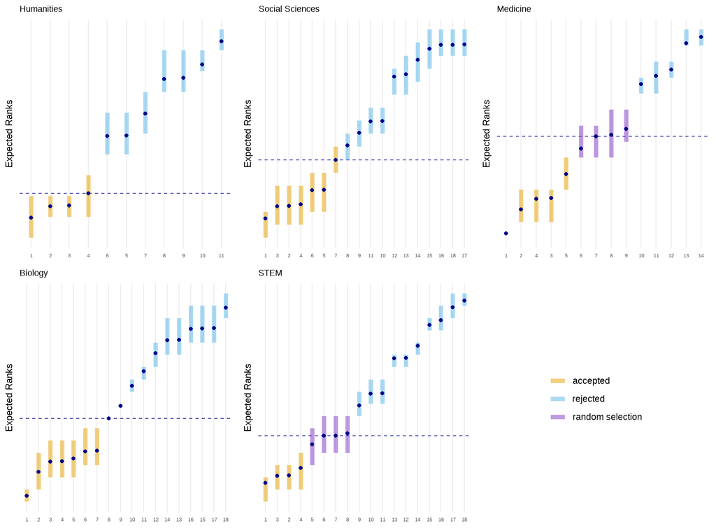

Figure 1.3: The expected rank together with 50% credible intervals of the rank.

```r
plot_er_dist_humanities <-
  plot_er_distributions(get_mcmc_samples_result = mcmc_hss_h_object,
                        n_proposals = hss_h %>%
                          summarise(n_distinct(proposal)) %>% pull(),
                        name_er = "rank_theta", title = "Humanities",
                        number_fundable = how_many_fundable["hss_h"],
                        outer_show = FALSE, proposal = "")


plot_er_dist_social_sciences <-
  plot_er_distributions(get_mcmc_samples_result = mcmc_hss_s_object,
                        n_proposals = hss_s %>%
                          summarise(n_distinct(proposal)) %>% pull(),
                        name_er = "rank_theta", title = "Social Sciences",
                        number_fundable = how_many_fundable["hss_s"],
                        outer_show = FALSE, proposal = "")
plot_er_dist_biology <-
  plot_er_distributions(get_mcmc_samples_result = mcmc_ls_b_object,
                        n_proposals = ls_b %>%
                          summarise(n_distinct(proposal)) %>% pull(),
                        name_er = "rank_theta", title = "Biology",
                        number_fundable = how_many_fundable["ls_b"],
                        outer_show = FALSE, proposal = "")

plot_er_dist_medicine <-
  plot_er_distributions(get_mcmc_samples_result = mcmc_ls_m_object,
                        n_proposals = ls_m %>%
                          summarise(n_distinct(proposal)) %>% pull(),
                        name_er = "rank_theta", title = "Medicine",
                        number_fundable = how_many_fundable["ls_m"],
                        outer_show = FALSE, proposal = "")

plot_er_dist_stem <-
  plot_er_distributions(get_mcmc_samples_result = mcmc_stem_object,
                        n_proposals = stem %>%
                          summarise(n_distinct(proposal)) %>% pull(),
                        name_er = "rank_theta", title = "STEM",
                        number_fundable = how_many_fundable["stem"],
                        outer_show = FALSE, proposal = "")

leg <- cowplot::get_legend(plot_er_dist_stem)
gridExtra::grid.arrange(plot_er_dist_humanities +
                          theme(legend.position = "none",
                                title = element_text(size = 7)),
                        plot_er_dist_social_sciences +
                          theme(legend.position = "none",
                                title = element_text(size = 7)),
                        plot_er_dist_medicine +
                          theme(legend.position = "none",
                                title = element_text(size = 7)),
                        plot_er_dist_biology +
                          theme(legend.position = "none",
                                title = element_text(size = 7)),
                        plot_er_dist_stem +
                          theme(legend.position = "none",
                                title = element_text(size = 7)), leg, ncol = 3)
```

Finally, Figure 1.4 shows the posterior distributions of the *ν*<sub>*j*</sub>’s (the mean of the assessor effects) for all PM panels, estimated from the discussed proposals. If for a specific assessor *ν*<sub>*j*</sub> is on average negative, this means that assessor *j* is stricter compared to the other assessors in the panel and his/her stricter grades are corrected more. On the other hand, a *ν*<sub>*j*</sub> that is on average positive reflects the behaviour of a assessor who gives generally higher grades compared to the remaining assessors. In the STEM panel, we can observe an extreme assessor (assessor 18). Looking at the raw data, this makes total sense, as assessor 18 gives especially low grades compared to the other assessors (Cs to proposals to which others gave As and ABs).

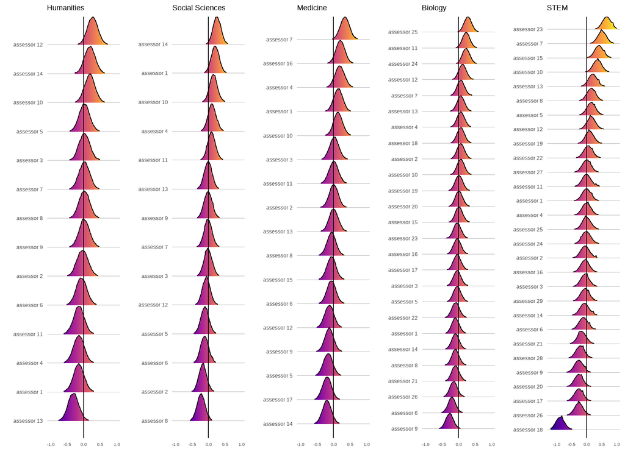

```r
plot_voter_humanities <-
  voter_behavior_distribution(get_mcmc_samples_result = mcmc_hss_h_object,
                              title = "Humanities",
                              names_voters = "assessor",
                              n_voters = hss_h %>%
                                summarise(n_distinct(voter)) %>% pull(),
                              xlim_min = -1, xlim_max = 1,
                              scale = 1)
plot_voter_social_sciences <-
  voter_behavior_distribution(get_mcmc_samples_result = mcmc_hss_s_object,
                              title = "Social Sciences",
                              names_voters = "assessor",
                              n_voters = hss_s %>%
                                summarise(n_distinct(voter)) %>% pull(),
                              xlim_min = -1, xlim_max = 1,
                              scale = 1)
plot_voter_biology <-
  voter_behavior_distribution(get_mcmc_samples_result = mcmc_ls_b_object,
                              title = "Biology",
                              names_voters = "assessor",
                              n_voters = ls_b %>%
                                summarise(n_distinct(voter)) %>% pull(),
                              xlim_min = -1, xlim_max = 1,
                              scale = 1)
plot_voter_medicine <-
  voter_behavior_distribution(get_mcmc_samples_result = mcmc_ls_m_object,
                              title = "Medicine",
                              names_voters = "assessor",
                              n_voters = ls_m %>%
                                summarise(n_distinct(voter)) %>% pull(),
                              xlim_min = -1, xlim_max = 1,
                              scale = 1)
plot_voter_stem <-
  voter_behavior_distribution(get_mcmc_samples_result = mcmc_stem_object,
                              title = "STEM",
                              names_voters = "assessor",
                              n_voters = stem %>%
                                summarise(n_distinct(voter)) %>% pull(),
                              xlim_min = -1.2, xlim_max = 1,
                              scale = 1)

gridExtra::grid.arrange(plot_voter_humanities, plot_voter_social_sciences,
                        plot_voter_medicine, plot_voter_biology,
                        plot_voter_stem, ncol = 5)
```

Instead of defining the random selection group using the ERs, we can directly use the proposal effects (*θ*<sub>*i*</sub>’s). Figure 1.5 shows the *θ*<sub>*i*</sub>’s together with their 50%-Crl, the higher the *θ*<sub>*i*</sub> the better the quality of the proposal. The division into the maximum of three groups (accepted, rejected and random selection) is the same using the proposal effects as with the expected rank for all panels, but for the Social Sciences, where a random selection would be applied on two proposals.

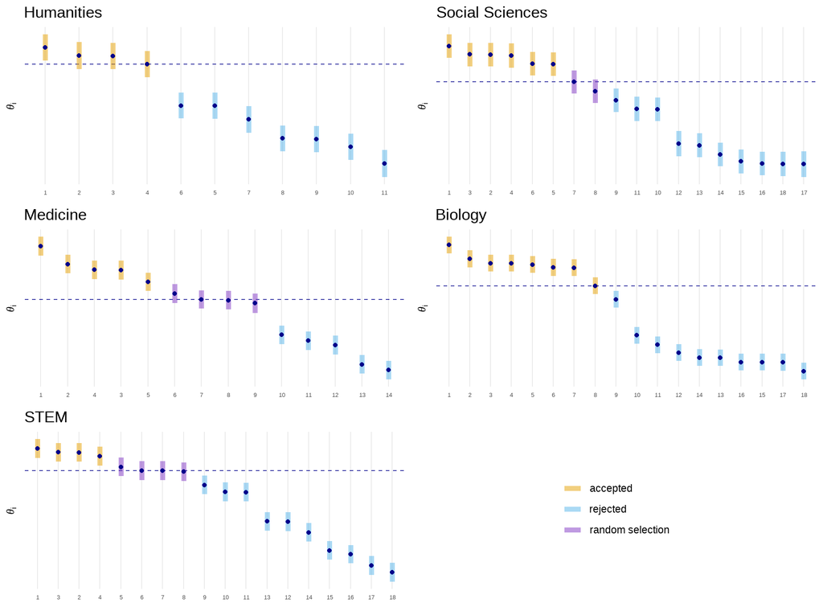

Figure 1.5: The means of the posterior distributions of the *θ*<sub>*i*</sub>’s together with their 50% credible intervals for the PM fellowship proposals. The dashed blue line is the naive funding line, *e*.*g* the posterior mean of the distribution of the *θ*<sub>*i*</sub> of the last fundable proposal.

```r
plot_theta_dist_humanities <-
  plot_er_distributions(get_mcmc_samples_result = mcmc_hss_h_object,
                        n_proposals = hss_h %>%
                          summarise(n_distinct(proposal)) %>% pull(),
                        name_er_or_theta = "application_intercept",
                        title = "Humanities", er = FALSE,
                        number_fundable = how_many_fundable["hss_h"],
                        outer_show = FALSE, proposal = "",
                        ylab = expression(theta[i]))

plot_theta_dist_social_sciences <-
  plot_er_distributions(get_mcmc_samples_result = mcmc_hss_s_object,
                        n_proposals = hss_s %>%
                          summarise(n_distinct(proposal)) %>% pull(),
                        name_er_or_theta = "application_intercept",
                        er = FALSE, title = "Social Sciences",
                        number_fundable = how_many_fundable["hss_s"],
                        outer_show = FALSE, proposal = "",
                        ylab = expression(theta[i]))
plot_theta_dist_biology <-
  plot_er_distributions(get_mcmc_samples_result = mcmc_ls_b_object,
                        n_proposals = ls_b %>%
                          summarise(n_distinct(proposal)) %>% pull(),
                        name_er_or_theta = "application_intercept",
                        er = FALSE, title = "Biology",
                        number_fundable = how_many_fundable["ls_b"],
                        outer_show = FALSE, proposal = "",
                        ylab = expression(theta[i]))

plot_theta_dist_medicine <-
  plot_er_distributions(get_mcmc_samples_result = mcmc_ls_m_object,
                        n_proposals = ls_m %>%
                          summarise(n_distinct(proposal)) %>% pull(),
                        name_er_or_theta = "application_intercept",
                        er = FALSE, title = "Medicine",
                        number_fundable = how_many_fundable["ls_m"],
                        outer_show = FALSE, proposal = "",
                        ylab = expression(theta[i]))

plot_theta_dist_stem <-
  plot_er_distributions(get_mcmc_samples_result = mcmc_stem_object,
                        n_proposals = stem %>%
                          summarise(n_distinct(proposal)) %>% pull(),
                        name_er_or_theta = "application_intercept",
                        er = FALSE, title = "STEM",
                        number_fundable = how_many_fundable["stem"],
                        outer_show = FALSE, proposal = "",
                        ylab = expression(theta[i]))

gridExtra::grid.arrange(plot_theta_dist_humanities +
                          theme(legend.position = "none"),
                        plot_theta_dist_social_sciences +
                          theme(legend.position = "none"),
                        plot_theta_dist_medicine +
                          theme(legend.position = "none"),
                        plot_theta_dist_biology +
                          theme(legend.position = "none"),
                        plot_theta_dist_stem +
                          theme(legend.position = "none"), leg, ncol = 2)
```

As discussed in the main paper, other quantities derived from the ER can be of interest. The ordered PCER of the proposals in the different panels can be found in Figure 1.6. Note that the lower the PCER, the better the quality of the proposal compared to all competing proposals. The lowest PCER in the Medicine panel is for example 5.5%, meaning that the probability that the best ranked proposal is of worse quality compared to a randomly selected proposal (including itself) is only 5.5%.

[figure not shown]

Figure 1.6: The PCER of the ranked proposals for all the PM panels.

```r
plot_pcer_humanities <- ranks_hss_h$rankings %>%
  arrange(pcer) %>%
  ggplot(aes(x = 1:11, y = pcer/100)) +
  geom_point() +
  theme_minimal() +
  labs(x = " ",
       y = "PCER",
       title = "Humanities") +
  theme(legend.position = "none",
        axis.ticks.x = element_line(color = "darkgray"),
        panel.grid.minor.x = element_blank(),
        panel.grid.minor.y = element_blank()) +
  scale_y_continuous(limits = c(0, 1), labels = scales::percent) +
  scale_x_continuous(breaks = 1:11,
                     labels = 1:11)

plot_pcer_soc_sciences <- ranks_hss_s$rankings %>%
  arrange(pcer) %>%
  ggplot(aes(x = 1:18, y = pcer/100)) +
  geom_point() +
  theme_minimal() +
  labs(x = " ",
       y = " ",
       title = "Social Sciences") +
  theme(legend.position = "none",
        axis.ticks.x = element_line(color = "darkgray"),
        panel.grid.minor.x = element_blank(),
        panel.grid.minor.y = element_blank()) +
  scale_y_continuous(limits = c(0, 1), labels = scales::percent) +
  scale_x_continuous(breaks = 1:18,
                     labels = 1:18)

plot_pcer_biology <- ranks_ls_b$rankings %>%
  arrange(pcer) %>%
  ggplot(aes(x = 1:18, y = pcer/100)) +
  geom_point() +
  theme_minimal() +
  labs(x = "Proposals ranked based on PCER",
       y = "PCER",
       title = "Biology") +
  theme(legend.position = "none",
        axis.ticks.x = element_line(color = "darkgray"),
        panel.grid.minor.x = element_blank(),
        panel.grid.minor.y = element_blank()) +
  scale_y_continuous(limits = c(0, 1), labels = scales::percent) +
  scale_x_continuous(breaks = 1:18,
                     labels = 1:18)

plot_pcer_medicine <- ranks_ls_m$rankings %>%
  arrange(pcer) %>%
  ggplot(aes(x = 1:14, y = pcer/100)) +
  geom_point() +
  theme_minimal() +
  labs(x = " ",
       y = " ",
       title = "Medicine") +
  theme(legend.position = "none",
        axis.ticks.x = element_line(color = "darkgray"),
        panel.grid.minor.x = element_blank(),
        panel.grid.minor.y = element_blank()) +
  scale_y_continuous(limits = c(0, 1), labels = scales::percent) +
  scale_x_continuous(breaks = 1:14,
                     labels = 1:14)

plot_pcer_stem <- ranks_stem$rankings %>%
  arrange(pcer) %>%
  ggplot(aes(x = 1:18, y = pcer/100)) +
  geom_point() +
  theme_minimal() +
  labs(x = "Proposals ranked based on PCER",
       y = " ",
       title = "Biology") +
  theme(legend.position = "none",
        axis.ticks.x = element_line(color = "darkgray"),
        panel.grid.minor.x = element_blank(),
        panel.grid.minor.y = element_blank()) +
  scale_y_continuous(limits = c(0, 1), labels = scales::percent) +
  scale_x_continuous(breaks = 1:18,
                     labels = 1:18)



gridExtra::grid.arrange(plot_pcer_humanities, plot_pcer_soc_sciences,
                        plot_pcer_medicine, plot_pcer_biology,
                        plot_pcer_stem, ncol = 3)
```

Another related quantity discussed in the main paper is the SUCRA, which is the surface under the cumulative ranking probability (CRP) plot. The latter can simply be plotted using the MCMC samples of the model parameters. Figures 1.7 gives an example of the this plot for the Humanities panel. The SUCRA of each proposal is written insight the CRP plots. Every proposal has its own CRP plot. Like the PCER, the SUCRA is independent of the number of proposals ranked.

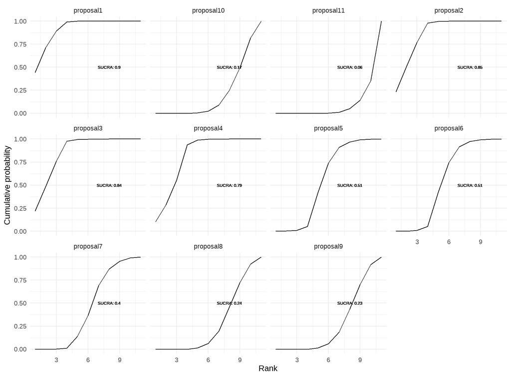

Figure 1.7: Cumulative ranking probability plots for the competing proposals in the Humanities Panel.

```r
plot_rankogram(data = hss_h,
               id_application = "proposal",
               id_voter = "voter",
               grade_variable = "num_grade",
               rank_theta_name = "rank_theta",
               cumulative_rank_prob = TRUE,
               mcmc_samples = mcmc_hss_h_object)
```

```r
# Ordinal version of the JAGS model:
seed_ordinal <- seed + 1
mcmc_hss_s_ordinal <-
  get_mcmc_samples(data = hss_s,
                   id_application = "proposal",
                   id_voter = "voter",
                   grade_variable = "num_grade",
                   n_chains = n.chains, n_iter = n.iter,
                   n_burnin = n.burnin, n_adapt = n.adapt,
                   ordinal_scale = TRUE, point_scale = 6,
                   max_iter =  max.iter,
                   rhat_threshold = 1.1,
                   inits_type = "random",
                   seed = seed_ordinal, quiet = TRUE)
```

```
## [1] "Be aware that the default ordinal model fixes the outcome to a six-\n          point scale."
```

```r
mcmc_hss_h_ordinal <-
  get_mcmc_samples(data = hss_h,
                   id_application = "proposal",
                   id_voter = "voter",
                   grade_variable = "num_grade",
                   n_chains = n.chains, n_iter = n.iter,
                   n_burnin = n.burnin, n_adapt = n.adapt,
                   ordinal_scale = TRUE, point_scale = 6,
                   max_iter =  max.iter,
                   rhat_threshold = 1.1,
                   inits_type = "random",
                   seed = seed_ordinal, quiet = TRUE)
```

```
## [1] "Be aware that the default ordinal model fixes the outcome to a six-\n          point scale."
```

```r
mcmc_ls_b_ordinal <-
  get_mcmc_samples(data = ls_b,
                   id_application = "proposal",
                   id_voter = "voter",
                   grade_variable = "num_grade",
                   n_chains = n.chains, n_iter = n.iter,
                   n_burnin = n.burnin, n_adapt = n.adapt,
                   ordinal_scale = TRUE, point_scale = 6,
                   max_iter =  max.iter,
                   rhat_threshold = 1.1,
                   inits_type = "random",
                   seed = seed_ordinal, quiet = TRUE)
```

```
## [1] "Be aware that the default ordinal model fixes the outcome to a six-\n          point scale."
## [1] "Caution: Even after increasing the adaption phase to 10000 iterations, the burnin phase to 10000 and the number of iterations to 50000 the max of the Rhat values is 1.16 e.g. > 1.1. The problematic parameter(s) is (are): sigma, tau_voter."
```

```r
mcmc_ls_m_ordinal <-
  get_mcmc_samples(data = ls_m,
                   id_application = "proposal",
                   id_voter = "voter",
                   grade_variable = "num_grade",
                   n_chains = n.chains, n_iter = n.iter,
                   n_burnin = n.burnin, n_adapt = n.adapt,
                   ordinal_scale = TRUE, point_scale = 6,
                   max_iter =  max.iter,
                   rhat_threshold = 1.1,
                   inits_type = "random",
                   seed = seed_ordinal, quiet = TRUE)
```

```
## [1] "Be aware that the default ordinal model fixes the outcome to a six-\n          point scale."
```

```r
n.iter <- 100000
mcmc_stem_ordinal <-
  get_mcmc_samples(data = stem,
                   id_application = "proposal",
                   id_voter = "voter",
                   grade_variable = "num_grade",
                   n_chains = n.chains, n_iter = n.iter,
                   n_burnin = n.burnin, n_adapt = n.adapt,
                   ordinal_scale = TRUE, point_scale = 6,
                   max_iter =  max.iter,
                   rhat_threshold = 1.1,
                   inits_type = "random",
                   seed = seed_ordinal, quiet = TRUE)
```

```
## [1] "Be aware that the default ordinal model fixes the outcome to a six-\n          point scale."
```

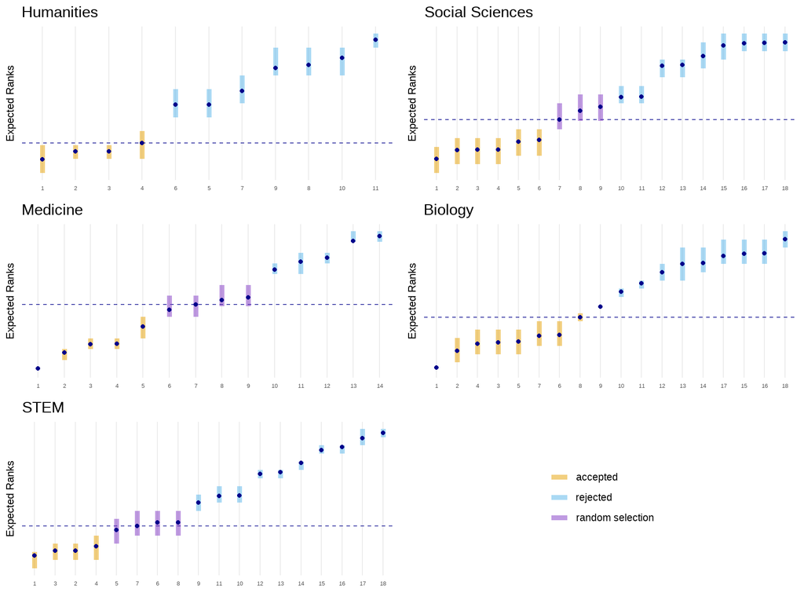

Figure 1.8: The expected rank together with 50% credible intervals of the rank using an ordinal outcome model.

```r
plot_er_dist_humanities_ordinal <-
  plot_er_distributions(get_mcmc_samples_result = mcmc_hss_h_ordinal,
                        n_proposals = hss_h %>%
                          summarise(n_distinct(proposal)) %>% pull(),
                        name_er_or_theta = "rank_theta", title = "Humanities",
                        number_fundable = how_many_fundable["hss_h"],
                        outer_show = FALSE, proposal = "")

plot_er_dist_social_sciences_ordinal <-
  plot_er_distributions(get_mcmc_samples_result = mcmc_hss_s_ordinal,
                        n_proposals = hss_s %>%
                          summarise(n_distinct(proposal)) %>% pull(),
                        name_er_or_theta = "rank_theta", title = "Social Sciences",
                        number_fundable = how_many_fundable["hss_s"],
                        outer_show = FALSE, proposal = "")

plot_er_dist_biology_ordinal <-
  plot_er_distributions(get_mcmc_samples_result = mcmc_ls_b_ordinal,
                        n_proposals = ls_b %>%
                          summarise(n_distinct(proposal)) %>% pull(),
                        name_er_or_theta = "rank_theta", title = "Biology",
                        number_fundable = how_many_fundable["ls_b"],
                        outer_show = FALSE, proposal = "")

plot_er_dist_medicine_ordinal <-
  plot_er_distributions(get_mcmc_samples_result = mcmc_ls_m_ordinal,
                        n_proposals = ls_m %>%
                          summarise(n_distinct(proposal)) %>% pull(),
                        name_er_or_theta = "rank_theta", title = "Medicine",
                        number_fundable = how_many_fundable["ls_m"],
                        outer_show = FALSE, proposal = "")

plot_er_dist_stem_ordinal <-
  plot_er_distributions(get_mcmc_samples_result = mcmc_stem_ordinal,
                        n_proposals = stem %>%
                          summarise(n_distinct(proposal)) %>% pull(),
                        name_er_or_theta = "rank_theta", title = "STEM",
                        number_fundable = how_many_fundable["stem"],
                        outer_show = FALSE, proposal = "")

leg <- cowplot::get_legend(plot_er_dist_stem_ordinal)
gridExtra::grid.arrange(plot_er_dist_humanities_ordinal +
                          theme(legend.position = "none"),
                        plot_er_dist_social_sciences_ordinal +
                          theme(legend.position = "none"),
                        plot_er_dist_medicine_ordinal +
                          theme(legend.position = "none"),
                        plot_er_dist_biology_ordinal +
                          theme(legend.position = "none"),
                        plot_er_dist_stem_ordinal +
                          theme(legend.position = "none"), leg, ncol = 2)
```

Figure 1.9 shows the Bland-Altman plots comparing the continuous and ordinal model for the five Postdoc.Mobility panels

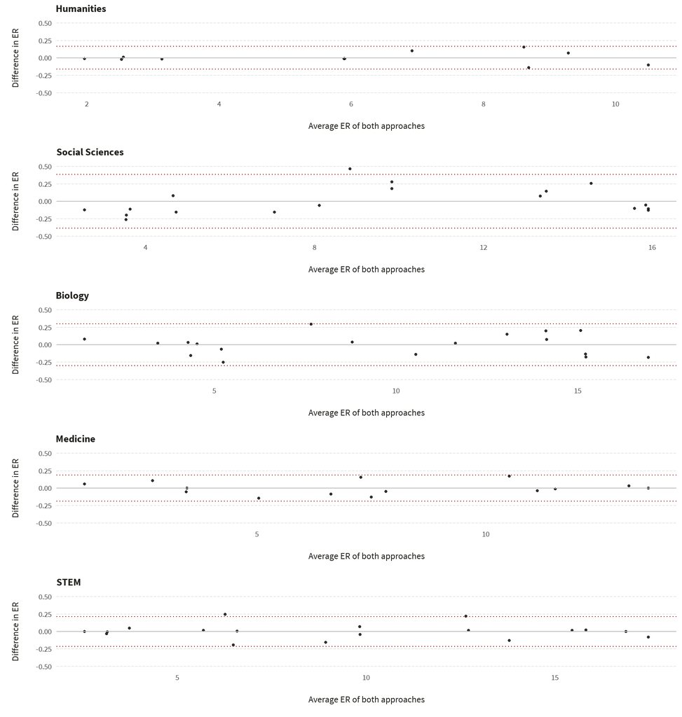

Figure 1.9: Difference in expected rank depending on whether the outcome is modeled as continuous or ordinal variable versus the average ER as computed using the continuous and ordinal outcome model. The 95% limits of agreement are plotted (red dotted lines) as well as the mean difference (gray line, bias), for the five panels evaluating the Postdoc.Mobility proposals.

```r
# Computation of the ordinal ERs:
ranks_hss_s_ordinal <- get_er_from_jags(data = hss_s,
                                        id_application = "proposal",
                                        id_voter = "voter",
                                        grade_variable = "num_grade",
                                        mcmc_samples = mcmc_hss_s_ordinal)

ranks_hss_h_ordinal <- get_er_from_jags(data = hss_h,
                                        id_application = "proposal",
                                        id_voter = "voter",
                                        grade_variable = "num_grade",
                                        mcmc_samples = mcmc_hss_h_ordinal)

ranks_ls_b_ordinal <- get_er_from_jags(data = ls_b,
                                       id_application = "proposal",
                                       id_voter = "voter",
                                       grade_variable = "num_grade",
                                       mcmc_samples = mcmc_ls_b_ordinal)

ranks_ls_m_ordinal <- get_er_from_jags(data = ls_m,
                                       id_application = "proposal",
                                       id_voter = "voter",
                                       grade_variable = "num_grade",
                                       mcmc_samples = mcmc_ls_m_ordinal)

ranks_stem_ordinal <- get_er_from_jags(data = stem,
                                       id_application = "proposal",
                                       id_voter = "voter",
                                       grade_variable = "num_grade",
                                       mcmc_samples = mcmc_stem_ordinal)

gridExtra::grid.arrange(get_agreement_plot(ranks_hss_h$rankings,
                                           ranks_hss_h_ordinal$rankings,
                                           title = "Humanities"),
                        get_agreement_plot(ranks_hss_s$rankings,
                                           ranks_hss_s_ordinal$rankings,
                                           title = "Social Sciences"),
                        get_agreement_plot(ranks_ls_b$rankings,
                                           ranks_ls_b_ordinal$rankings,
                                           title = "Biology"),
                        get_agreement_plot(ranks_ls_m$rankings,
                                           ranks_ls_m_ordinal$rankings,
                                           title = "Medicine"),
                        get_agreement_plot(ranks_stem$rankings,
                                           ranks_stem_ordinal$rankings,
                                           title = "STEM"),
                        ncol = 1)
```

```r
rm(mcmc_hss_h_ordinal,
   mcmc_stem_ordinal,
   mcmc_hss_s_ordinal,
   mcmc_ls_b_ordinal,
   mcmc_ls_m_ordinal,
   mcmc_hss_s_object,
   mcmc_hss_h_object,
   mcmc_stem_object,
   mcmc_hss_h,
   mcmc_hss_s,
   mcmc_stem,
   mcmc_ls_b,
   mcmc_ls_m)
```

# 2 Project Funding

(Note that to make this online supplement run faster you would have to decrease the number of iterations, adaptation, and burnin for the following example. We used a high number, to ensure the convergence of all the chains (for the results presented in the manuscript.)

Project funding (PF) is the SNSF’s most important funding instrument. PF grants are meant for research proposals with a topic of the applicant’s own choice. The data that we will analyze in the following originates from the evaluation of the April 2020 Call to the Mathematics, Natural and Engineering Sciences (MINT) Division. All in all, 353 grant proposals were evaluated in the MINT division. To ensure a manageable amount of work to be spread among the panel members and the quality of the reviews and gradings, the evaluation was done in four separate sections. The sections were defined as such that they were of similar sizes and had a similar number of international members and female members. This approach ensures that the section compositions are comparable. Each section did indeed define their own funding line, while keeping the success rate in each section the same ($∼ 30%$). Table 2.1 shows the number of proposals evaluated and fundable by section (nine members are present in each section). The number of fundable proposals will be defined as $∼ 30%$ of the number of evaluated proposals. Each section member or assessor has to individually evaluate each proposal in their section (unless they have a conflict of interest or another reason to be absent during the vote). The average evaluation scores (6=A, $…$, 1=D) given to all the proposals in each section and the averages of the fundable proposals ($30%$ best ranked according to their average score) are also shown.

Table 2.1: Summarising statistics in the four sections of the MINT division in Project Funding.

| Section | N. of proposals | N. of fundable proposa | Avg score | Avg score of 30% best |
| --- | --- | --- | --- | --- |
| one | 87 | 26 | 3.84 | 5.01 |
| two | 92 | 28 | 3.81 | 5.02 |
| three | 86 | 26 | 3.97 | 5.24 |
| four | 88 | 26 | 3.73 | 5.04 |

To understand how reliably the assessors’ evaluations were in the different sections, we refer to Figure 2.1. Compared to the previous Postdoc.Mobility case study, the intra-class correlation coefficients are higher and can be classified as good. One reason for the higher reliability here is that *all* project funding proposals are included - also the ones with low/high average scores, for which the votes are usually less variable. (In contrast, we only looked at PM proposals with average scores in the middle range.)

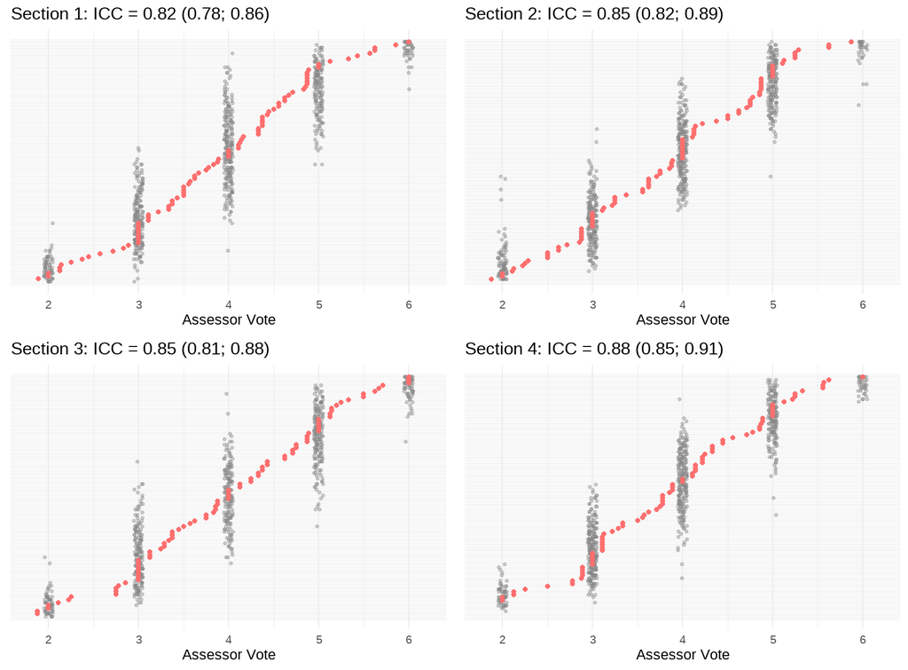

Figure 2.1: The individual votes given to all proposals by all panel members. The red dots represent the averages of those individual votes for each proposal. The intra-class correlation coefficients (ICC) together with their 95% confidence intervals of the different panels can be found in the titles of the subfigures. The overall reliability in the those panels can be classified as good.

```r
leg <- cowplot::get_legend(get_grades_plot(mint_section1))
gridExtra::grid.arrange(get_grades_plot(mint_section1, mint_section1_mat,
                                        x_min = 1.8, title = "Section 1",
                                        jitter_alpha = .4, jitter_w = .05) +
                          theme(legend.position = "none"),
                        get_grades_plot(mint_section2, mint_section2_mat,
                                        x_min = 1.8, title = "Section 2",
                                        jitter_alpha = .4, jitter_w = .05) +
                          theme(legend.position = "none"),
                        get_grades_plot(mint_section3, mint_section3_mat,
                                        x_min = 1.8, title = "Section 3",
                                        jitter_alpha = .4, jitter_w = .05)+
                          theme(legend.position = "none"),
                        get_grades_plot(mint_section4, mint_section4_mat,
                                        x_min = 1.8, title = "Section 4",
                                        jitter_alpha = .4, jitter_w = .05) +
                          theme(legend.position = "none")#, leg
                        )
```

Then, as for the postdoc.mobility fellowships, Bayesian hierarchical models will be fitted for each of the four sections individually, but also for the pooled data and adding an additional section effect in the model definition. Afterwards the computation of the expected ranks (and the PCER) is straightforward using the MCMC samples from the latter models.

```r
#### JAGS model for continuous outcome ####
# default model
n.iter <- 400 * 10^{3}
n.burnin <- 150 * 10^{3}
n.adapt <- 100 * 10^{3}
n.chains <- 4
seed <- 1991
mcmc_mint_object <-
  get_mcmc_samples(data = mint_sections,
                   id_application = "proposal",
                   id_voter = "voter",
                   id_section =  "section",
                   grade_variable = "num_grade",
                   n_chains = n.chains, n_iter = n.iter,
                   n_burnin = n.burnin, n_adapt = n.adapt,
                   max_iter = 400 * 10^{3},
                   inits_type = "random",
                   rhat_threshold = 1.1,
                   variables_to_sample = "specified",
                   names_variables_to_sample =
                     c("tau_application", "tau_voter", "sigma",
                       "rank_theta", "tau_section"),
                   seed = seed, quiet = TRUE,
                   dont_bind = TRUE)
```

```r
# Section by section:
n.iter <- 120 * 10^{3}
n.burnin <- 30 * 10^{3}
n.adapt <- 30 * 10^{3}
n.chains <- 4
mcmc_mint_section1 <-
  ERforResearch:::get_mcmc_samples(data = mint_section1,
                                   id_application = "proposal",
                                   id_voter = "voter",
                                   grade_variable = "num_grade",
                                   n_chains = n.chains, n_iter = n.iter,
                                   n_burnin = n.burnin,
                                   n_adapt = n.adapt,
                                   max_iter = 120 * 10^{3},
                                   rhat_threshold = 1.1,
                                   inits_type = "random",
                                   seed = seed, quiet = TRUE)

mcmc_mint_section2 <-
  ERforResearch:::get_mcmc_samples(data = mint_section2,
                                   id_application = "proposal",
                                   id_voter = "voter",
                                   grade_variable = "num_grade",
                                   n_chains = n.chains, n_iter = n.iter,
                                   n_burnin = n.burnin,
                                   n_adapt = n.adapt,
                                   max_iter = 120 * 10^{3},
                                   rhat_threshold = 1.1,
                                   inits_type = "random",
                                   seed = seed, quiet = TRUE)

mcmc_mint_section3 <-
  ERforResearch:::get_mcmc_samples(data = mint_section3,
                                   id_application = "proposal",
                                   id_voter = "voter",
                                   grade_variable = "num_grade",
                                   n_chains = n.chains, n_iter = n.iter,
                                   n_burnin = n.burnin,
                                   n_adapt = n.adapt,
                                   max_iter = 120 * 10^{3},
                                   rhat_threshold = 1.1,
                                   inits_type = "random",
                                   seed = seed, quiet = TRUE)

mcmc_mint_section4 <-
  ERforResearch:::get_mcmc_samples(data = mint_section4,
                                   id_application = "proposal",
                                   id_voter = "voter",
                                   grade_variable = "num_grade",
                                   n_chains = n.chains, n_iter = n.iter,
                                   n_burnin = n.burnin,
                                   n_adapt = n.adapt,
                                   max_iter = 120 * 10^{3},
                                   rhat_threshold = 1.1,
                                   inits_type = "random",
                                   seed = seed, quiet = TRUE)


ranks_mint <-
  get_er_from_jags(data = mint_sections,
                   id_application = "proposal",
                   id_voter = "voter",
                   id_section =  "section",
                   grade_variable = "num_grade",
                   tau_section_name = "tau_section",
                   mcmc_samples = mcmc_mint_object,
                   seed = seed, rank_pm = FALSE)

# Section by section:

ranks_mint_section1 <-
  get_er_from_jags(data = mint_section1,
                   id_application = "proposal",
                   id_voter = "voter",
                   grade_variable = "num_grade",
                   mcmc_samples = mcmc_mint_section1,
                   seed = seed, rank_pm = FALSE)

ranks_mint_section2 <-
  get_er_from_jags(data = mint_section2,
                   id_application = "proposal",
                   id_voter = "voter",
                   grade_variable = "num_grade",
                   mcmc_samples = mcmc_mint_section2,
                   seed = seed, rank_pm = FALSE)

ranks_mint_section3 <-
  get_er_from_jags(data = mint_section3,
                   id_application = "proposal",
                   id_voter = "voter",
                   grade_variable = "num_grade",
                   mcmc_samples = mcmc_mint_section3,
                   seed = seed, rank_pm = FALSE)

ranks_mint_section4 <-
  get_er_from_jags(data = mint_section4,
                   id_application = "proposal",
                   id_voter = "voter",
                   grade_variable = "num_grade",
                   mcmc_samples = mcmc_mint_section4,
                   seed = seed, rank_pm = FALSE)
```

```r
#### JAGS model for ordinal outcome ####
n.iter <- 400 * 10^{3}
n.burnin <- 150 * 10^{3}
n.adapt <- 100 * 10^{3}
n.chains <- 4
seed_ordinal <- seed + 1
mcmc_mint_ordinal <-
  get_mcmc_samples(data = mint_sections,
                   id_application = "proposal",
                   id_voter = "voter",
                   id_section =  "section",
                   grade_variable = "num_grade",
                   tau_section_name = "tau_section",
                   n_chains = n.chains, n_iter = n.iter,
                   n_burnin = n.burnin, n_adapt = n.adapt,
                   max_iter = 400 * 10^{3},
                   rhat_threshold = 1.1,
                   inits_type = "random",
                   ordinal_scale = TRUE,
                   point_scale = 6,
                   seed = seed_ordinal, quiet = TRUE)
```

```r
# Section by section:
n.iter <- 120 * 10^{3}
n.burnin <- 30 * 10^{3}
n.adapt <- 30 * 10^{3}
n.chains <- 4

mcmc_mint_section1_ordinal <-
  get_mcmc_samples(data = mint_section1,
                   id_application = "proposal",
                   id_voter = "voter",
                   grade_variable = "num_grade",
                   n_chains = n.chains, n_iter = n.iter,
                   n_burnin = n.burnin, n_adapt = n.adapt,
                   max_iter = 120 * 10^{3},
                   rhat_threshold = 1.1,
                   inits_type = "random",
                   ordinal_scale = TRUE,
                   point_scale = 6,
                   seed = seed_ordinal, quiet = TRUE)

mcmc_mint_section2_ordinal <-
    get_mcmc_samples(data = mint_section2,
                     id_application = "proposal",
                     id_voter = "voter",
                     grade_variable = "num_grade",
                     n_chains = n.chains, n_iter = n.iter,
                     n_burnin = n.burnin, n_adapt = n.adapt,
                     max_iter = 120 * 10^{3},
                     rhat_threshold = 1.1,
                     inits_type = "random",
                     ordinal_scale = TRUE,
                     point_scale = 6,
                     seed = seed_ordinal, quiet = TRUE)

mcmc_mint_section3_ordinal <-
  get_mcmc_samples(data = mint_section3,
                   id_application = "proposal",
                   id_voter = "voter",
                   grade_variable = "num_grade",
                   n_chains = n.chains, n_iter = n.iter,
                   n_burnin = n.burnin, n_adapt = n.adapt,
                   max_iter = 120 * 10^{3},
                   rhat_threshold = 1.1,
                   inits_type = "random",
                   ordinal_scale = TRUE,
                   point_scale = 6,
                   seed = seed_ordinal, quiet = TRUE)

mcmc_mint_section4_ordinal <-
    get_mcmc_samples(data = mint_section4,
                     id_application = "proposal",
                     id_voter = "voter",
                     grade_variable = "num_grade",
                     n_chains = n.chains, n_iter = n.iter,
                     n_burnin = n.burnin, n_adapt = n.adapt,
                     max_iter = 120 * 10^{3},
                     rhat_threshold = 1.1,
                     inits_type = "random",
                     ordinal_scale = TRUE,
                     point_scale = 6,
                     seed = seed_ordinal, quiet = TRUE)

ranks_mint_ordinal <-
  get_er_from_jags(data = mint_sections,
                   id_application = "proposal",
                   id_voter = "voter",
                   id_section =  "section",
                   grade_variable = "num_grade",
                   tau_section_name = "tau_section",
                   mcmc_samples = mcmc_mint_ordinal,
                   ordinal_scale = TRUE,
                   point_scale = 6,
                   seed = seed)

# Section by Section:
ranks_mint_section1_ordinal <-
  get_er_from_jags(data = mint_section1,
                   id_application = "proposal",
                   id_voter = "voter",
                   grade_variable = "num_grade",
                   mcmc_samples = mcmc_mint_section1_ordinal,
                   ordinal_scale = TRUE,
                   point_scale = 6,
                   seed = seed_ordinal)

ranks_mint_section2_ordinal <-
  get_er_from_jags(data = mint_section2,
                   id_application = "proposal",
                   id_voter = "voter",
                   grade_variable = "num_grade",
                   mcmc_samples = mcmc_mint_section2_ordinal,
                   seed = seed_ordinal)

ranks_mint_section3_ordinal <-
  get_er_from_jags(data = mint_section3,
                   id_application = "proposal",
                   id_voter = "voter",
                   grade_variable = "num_grade",
                   mcmc_samples = mcmc_mint_section3_ordinal,
                   seed = seed_ordinal)

ranks_mint_section4_ordinal <-
  get_er_from_jags(data = mint_section4,
                   id_application = "proposal",
                   id_voter = "voter",
                   grade_variable = "num_grade",
                   mcmc_samples = mcmc_mint_section4_ordinal,
                   seed = seed_ordinal)
```

Figure 2.2 shows the resulting expected ranks for each of the sections separately. The proposals are first ranked based on their average score (Fixed Ranking) to then compute the ER. Remember that, each section will define a separate funding line. Note that rank 1 is reserved for the best proposal according to its quality assessment. The best ERs are 1.44 for section one, 1.26 for section two, 2.26 for section three and 1.08 for section four; so very close to 1. The worst ERs are 86.28 for section one, 92 for section two, 85.9 for section three and 87.19 for section four, which are all very close to the total number of submissions.

```r
# mcmc_mint_section1$samples <-
#   mcmc_mint_section1$samples[sample(1:240000, 24000),]
# mcmc_mint_section2$samples <-
#   mcmc_mint_section2$samples[sample(1:240000, 24000),]
# mcmc_mint_section3$samples <-
#   mcmc_mint_section3$samples[sample(1:240000, 24000),]
# mcmc_mint_section4$samples <-
#   mcmc_mint_section4$samples[sample(1:240000, 24000),]

# mcmc_mint_object2$samples <-
mcmc_mint <- mcmc_mint_object
rm(mcmc_mint_object)
mcmc_mint$samples <- do.call("rbind", mcmc_mint$samples)
mcmc_mint$samples <- mcmc_mint$samples[sample(1:1600000, 100000),]

mcmc_mint_ordinal$samples <- mcmc_mint_ordinal$samples[sample(1:1600000, 100000),]
```